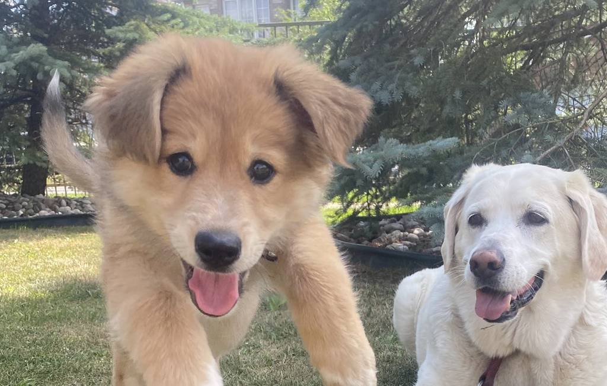

```python
from PIL import Image # Library for importing images
import pandas as pd # Library for working with datasets
import numpy as np # Library for calculations
Image.open('images/dog_jump.jpg').crop((100, 300, 1200, 1000))  # Crop the image
```

# Act Report

## Introduction

The dataset that we will be wrangling (and analyzing and visualizing) is the tweet archive of Twitter user @dog_rates, also known as WeRateDogs. WeRateDogs is a Twitter account that rates people's dogs with a humorous comment about the dog. These ratings almost always have a denominator of 10. The numerators, though? Almost always greater than 10. 11/10, 12/10, 13/10, etc. Why? Because "they're good dogs Brent." WeRateDogs has over 4 million followers and has received international media coverage.

**Dictionary:**

1. **pupper:** Puppy, a small doggo and usually younger.
2. **puppo:** A transitional phase between pupper and doggo. Easily understood as the dog equivalent of a teenager.
3. **doggo:** Dog, usually older.
4. **floofer:** Very fluffy dog or a dog with excess fur. Comical amounts of fur on a dog will certainly earn any dog this name.
5. **multiple_stages:** This means either multiple dogs have been entered in a tweet or a single dog has multiple stages. For example, a single dog can both be a pupper and a floofer.

## Analysing, and Visualizing Data

### 1. Most Popular Dog Types

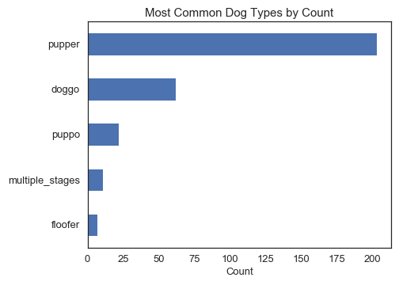

```python
Image.open('images/most_common_dog_types_by_count.png')
```

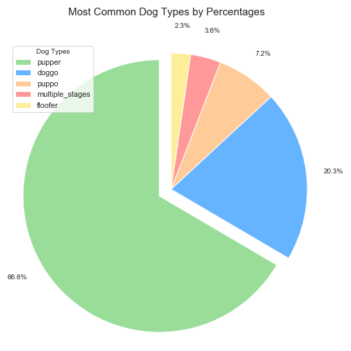

```python
Image.open('images/most_common_dog_types_by_percentages.png')
```

```python
pd.read_csv('tables/dog_count.csv').set_index('dog_type')
```

| dog_type | count |
| --- | --- |
| pupper | 203 |
| doggo | 62 |
| puppo | 22 |
| multiple_stages | 11 |
| floofer | 7 |